# SI 370 - Homework #5: Classifiers

or: How I Learned to Stop Worrying and Love Machine Learning

Version 2023.11.06.1.CT

This is, perhaps, one of the most exciting homework assignments that you have encountered in this course!

Similar to what we introduced you to last class, you are going to try your hand at a Kaggle competition to predict which passengers onboard the Spaceship Titanic will be transported to an alternate dimension.

(NOTE: if you prefer to not submit your work to the Kaggle competition that's fine -- just contact Chris via email (cteplovs@umich.edu) and we will work out an alternative.)

To start navigate to the [Spaceship Titanic](https://www.kaggle.com/competitions/spaceship-titanic) project page.

The basic steps for this assignment were outlined in the video from last class:

1. Accept the rules and join the competition
2. Download the data (from the data tab of the competition page)
3. Understand the problem
4. EDA (Exploratory Data Analysis)
5. Train, tune, and ensemble (!) your machine learning models
6. Upload your prediction as a submission on Kaggle and receive an accuracy score

additionally, you will

7. Upload your final notebook to Canvas and report your best accuracy score.

Note that class grades are not entirely dependent on your accuracy score.  
All models that achieve 80% accuracy will receive full points for the accuracy component of this assignment.

Some additional notes:

1. If you use another notebook, code, or approaches be sure to reference the original work. (Note that we recommend you study existing Kaggle notebooks before starting your own work.)
2. If you use ChatGPT, or any other generative AI helper, be sure to reference that as well.
3. You can help each other but in the end you must submit your own work, both to Kaggle and to Canvas.

Some additional resources:

- "ensemble" your models with a [VotingClassifier](https://scikit-learn.org/stable/modules/generated/sklearn.ensemble.VotingClassifier.html)
- a good primer on [feature engineering](https://triangleinequality.wordpress.com/2013/09/08/basic-feature-engineering-with-the-titanic-data/)
- There are a lot of good [notebooks to study](https://www.kaggle.com/competitions/spaceship-titanic/code) (check the number of upvotes to help guide your exploration)

## GOOD LUCK!

(and don't cheat... cheating on this assignment will result in a grade of zero.)

One final note: Your submission should be a self-contained notebook that is NOT based on this one. Studying the existing Kaggle competition notebooks should give you a sense of what makes a "good" notebook.

```python
pip install lightgbm
```

```python
import pandas as pd
import numpy as np
import seaborn as sns
import matplotlib.pyplot as plt


from sklearn.svm import SVC
from sklearn.naive_bayes import GaussianNB
from sklearn.linear_model import LogisticRegression
from sklearn.neighbors import KNeighborsClassifier
from sklearn.tree import DecisionTreeClassifier
from sklearn.ensemble import RandomForestClassifier, GradientBoostingClassifier, AdaBoostClassifier, StackingClassifier


from sklearn.impute import SimpleImputer
from sklearn.model_selection import train_test_split, GridSearchCV, RandomizedSearchCV
from sklearn.metrics import accuracy_score, f1_score, recall_score, precision_score, confusion_matrix
from sklearn.preprocessing import LabelEncoder, OneHotEncoder, StandardScaler, MinMaxScaler
from sklearn.pipeline import Pipeline
from sklearn.compose import ColumnTransformer

from sklearn.linear_model import LogisticRegression
from sklearn.tree import DecisionTreeClassifier
from sklearn.ensemble import RandomForestClassifier
from sklearn.svm import SVC
from sklearn.ensemble import AdaBoostClassifier
from sklearn.ensemble import GradientBoostingClassifier
from sklearn.ensemble import VotingClassifier
from sklearn.neural_network import MLPClassifier

from sklearn.model_selection import cross_val_score
```

```python
train_df = pd.read_csv('../data/spaceship-titanic/train.csv')
test_df = pd.read_csv('../data/spaceship-titanic/test.csv')
```

```python
train_df.shape
```

```
(8693, 14)
```

```python
train_df.head()
```

|  | PassengerId | HomePlanet | CryoSleep | Cabin | Destination | Age | VIP | RoomService | FoodCourt | ShoppingMall | Spa | VRDeck | Name | Transported |
| --- | --- | --- | --- | --- | --- | --- | --- | --- | --- | --- | --- | --- | --- | --- |
| 0 | 0001_01 | Europa | False | B/0/P | TRAPPIST-1e | 39.0 | False | 0.0 | 0.0 | 0.0 | 0.0 | 0.0 | Maham Ofracculy | False |
| 1 | 0002_01 | Earth | False | F/0/S | TRAPPIST-1e | 24.0 | False | 109.0 | 9.0 | 25.0 | 549.0 | 44.0 | Juanna Vines | True |
| 2 | 0003_01 | Europa | False | A/0/S | TRAPPIST-1e | 58.0 | True | 43.0 | 3576.0 | 0.0 | 6715.0 | 49.0 | Altark Susent | False |
| 3 | 0003_02 | Europa | False | A/0/S | TRAPPIST-1e | 33.0 | False | 0.0 | 1283.0 | 371.0 | 3329.0 | 193.0 | Solam Susent | False |
| 4 | 0004_01 | Earth | False | F/1/S | TRAPPIST-1e | 16.0 | False | 303.0 | 70.0 | 151.0 | 565.0 | 2.0 | Willy Santantines | True |

```python
train_df.describe()
```

|  | Age | RoomService | FoodCourt | ShoppingMall | Spa | VRDeck |
| --- | --- | --- | --- | --- | --- | --- |
| count | 8514.000000 | 8512.000000 | 8510.000000 | 8485.000000 | 8510.000000 | 8505.000000 |
| mean | 28.827930 | 224.687617 | 458.077203 | 173.729169 | 311.138778 | 304.854791 |
| std | 14.489021 | 666.717663 | 1611.489240 | 604.696458 | 1136.705535 | 1145.717189 |
| min | 0.000000 | 0.000000 | 0.000000 | 0.000000 | 0.000000 | 0.000000 |
| 25% | 19.000000 | 0.000000 | 0.000000 | 0.000000 | 0.000000 | 0.000000 |
| 50% | 27.000000 | 0.000000 | 0.000000 | 0.000000 | 0.000000 | 0.000000 |
| 75% | 38.000000 | 47.000000 | 76.000000 | 27.000000 | 59.000000 | 46.000000 |
| max | 79.000000 | 14327.000000 | 29813.000000 | 23492.000000 | 22408.000000 | 24133.000000 |

```python
train_df.isnull().sum()
```

```
PassengerId       0
HomePlanet      201
CryoSleep       217
Cabin           199
Destination     182
Age             179
VIP             203
RoomService     181
FoodCourt       183
ShoppingMall    208
Spa             183
VRDeck          188
Name            200
Transported       0
dtype: int64
```

```python
train_df.dtypes
```

```
PassengerId      object
HomePlanet       object
CryoSleep        object
Cabin            object
Destination      object
Age             float64
VIP              object
RoomService     float64
FoodCourt       float64
ShoppingMall    float64
Spa             float64
VRDeck          float64
Name             object
Transported        bool
dtype: object
```

```python
train_df.info
```

```
<bound method DataFrame.info of      PassengerId HomePlanet CryoSleep     Cabin    Destination   Age    VIP  \
0        0001_01     Europa     False     B/0/P    TRAPPIST-1e  39.0  False
1        0002_01      Earth     False     F/0/S    TRAPPIST-1e  24.0  False
2        0003_01     Europa     False     A/0/S    TRAPPIST-1e  58.0   True
3        0003_02     Europa     False     A/0/S    TRAPPIST-1e  33.0  False
4        0004_01      Earth     False     F/1/S    TRAPPIST-1e  16.0  False
...          ...        ...       ...       ...            ...   ...    ...
8688     9276_01     Europa     False    A/98/P    55 Cancri e  41.0   True
8689     9278_01      Earth      True  G/1499/S  PSO J318.5-22  18.0  False
8690     9279_01      Earth     False  G/1500/S    TRAPPIST-1e  26.0  False
8691     9280_01     Europa     False   E/608/S    55 Cancri e  32.0  False
8692     9280_02     Europa     False   E/608/S    TRAPPIST-1e  44.0  False

      RoomService  FoodCourt  ShoppingMall     Spa  VRDeck               Name  \
0             0.0        0.0           0.0     0.0     0.0    Maham Ofracculy
```

[output cut: 25 more lines]

```python
train_df.value_counts()
```

```
PassengerId  HomePlanet  CryoSleep  Cabin     Destination    Age   VIP    RoomService  FoodCourt  ShoppingMall  Spa    VRDeck  Name               Transported
0001_01      Europa      False      B/0/P     TRAPPIST-1e    39.0  False  0.0          0.0        0.0           0.0    0.0     Maham Ofracculy    False          1
6162_01      Earth       False      F/1181/S  55 Cancri e    22.0  False  0.0          0.0        1.0           575.0  0.0     Bonyan Hineyley    False          1
6175_01      Earth       False      G/1000/P  TRAPPIST-1e    18.0  False  628.0        0.0        0.0           31.0   150.0   Thel Pittler       False          1
6174_02      Earth       True       G/999/P   PSO J318.5-22  4.0   False  0.0          0.0        0.0           0.0    0.0     Cherry Fisheparks  True           1
6174_01      Earth       False      F/1274/P  55 Cancri e    24.0  False  0.0          479.0      116.0         1.0    37.0    Jord Mcbriddley    False          1
                                                                                                                                                                ..
3195_02      Earth       False      G/505/S   PSO J318.5-22  60.0  False  0.0          31.0       6.0           223.0  356.0   Fredy Litthews     False          1
3195_01      Earth       False      G/505/S   TRAPPIST-1e    1.0   False  0.0          0.0        0.0           0.0    0.0     Rald Litthews      False          1
3191_01      Mars        True       F/603/S   TRAPPIST-1e    68.0  False  0.0          0.0        0.0           0.0    0.0     Fex Sin            True           1
3189_01      Mars        True       D/102/P   55 Cancri e    40.0  False  0.0          0.0        0.0           0.0    0.0     Weers Che          True           1
9280_02      Europa      False      E/608/S   TRAPPIST-1e    44.0  False  126.0        4688.0     0.0           0.0    12.0    Propsh Hontichre   True           1
Name: count, Length: 6606, dtype: int64
```

```python
train_df.corr
```

```
<bound method DataFrame.corr of      PassengerId HomePlanet CryoSleep     Cabin    Destination   Age    VIP  \
0        0001_01     Europa     False     B/0/P    TRAPPIST-1e  39.0  False
1        0002_01      Earth     False     F/0/S    TRAPPIST-1e  24.0  False
2        0003_01     Europa     False     A/0/S    TRAPPIST-1e  58.0   True
3        0003_02     Europa     False     A/0/S    TRAPPIST-1e  33.0  False
4        0004_01      Earth     False     F/1/S    TRAPPIST-1e  16.0  False
...          ...        ...       ...       ...            ...   ...    ...
8688     9276_01     Europa     False    A/98/P    55 Cancri e  41.0   True
8689     9278_01      Earth      True  G/1499/S  PSO J318.5-22  18.0  False
8690     9279_01      Earth     False  G/1500/S    TRAPPIST-1e  26.0  False
8691     9280_01     Europa     False   E/608/S    55 Cancri e  32.0  False
8692     9280_02     Europa     False   E/608/S    TRAPPIST-1e  44.0  False

      RoomService  FoodCourt  ShoppingMall     Spa  VRDeck               Name  \
0             0.0        0.0           0.0     0.0     0.0    Maham Ofracculy
```

[output cut: 25 more lines]

```python
cross_tab = pd.crosstab(train_df['HomePlanet'], train_df['CryoSleep'])
cross_tab
```

| CryoSleep HomePlanet | False | True |
| --- | --- | --- |
| Earth | 3106 | 1382 |
| Europa | 1162 | 911 |
| Mars | 1047 | 669 |

```python
crosstab = pd.crosstab(train_df['Destination'], train_df['VIP'])
crosstab
```

| VIP Destination | False | True |
| --- | --- | --- |
| 55 Cancri e | 1692 | 65 |
| PSO J318.5-22 | 756 | 18 |
| TRAPPIST-1e | 5667 | 114 |

```python
train_df.dtypes
```

```
PassengerId      object
HomePlanet       object
CryoSleep        object
Cabin            object
Destination      object
Age             float64
VIP              object
RoomService     float64
FoodCourt       float64
ShoppingMall    float64
Spa             float64
VRDeck          float64
Name             object
Transported        bool
dtype: object
```

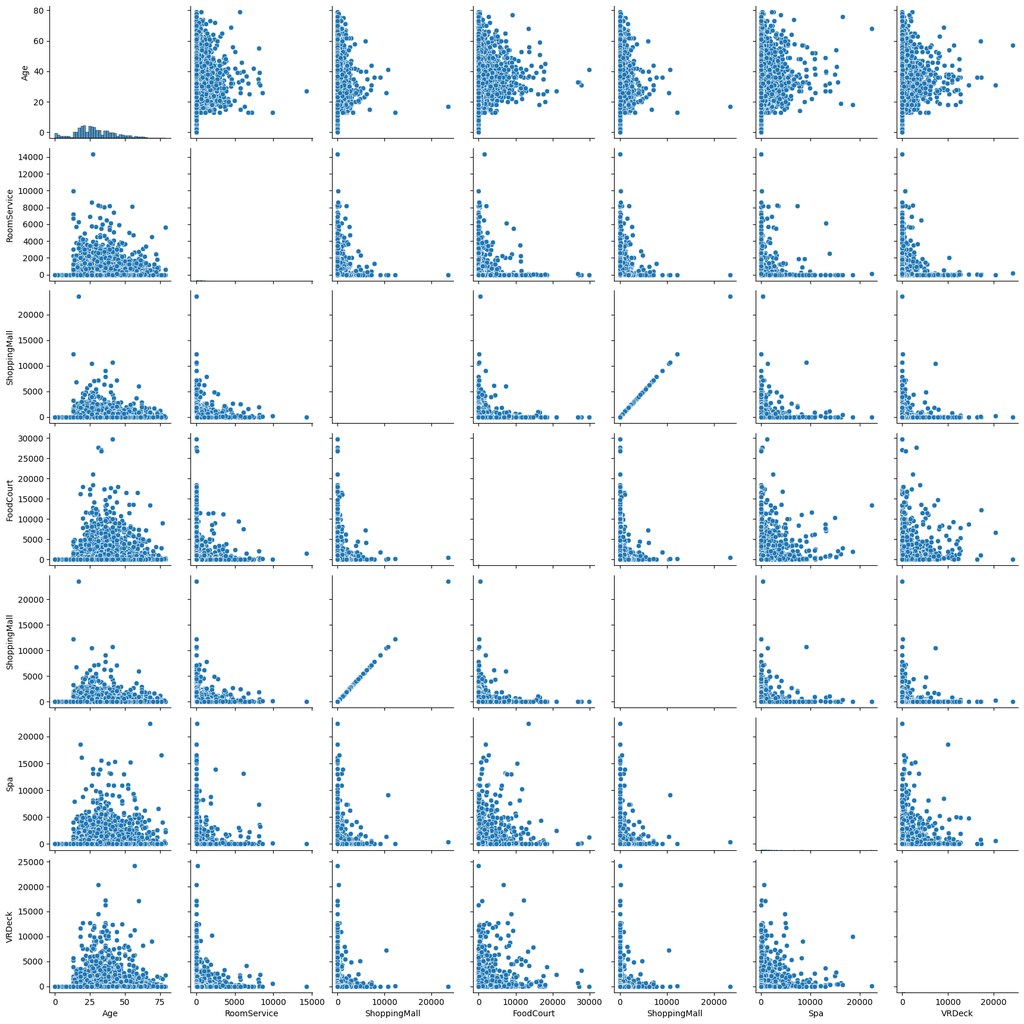

```python
sns.pairplot(train_df, vars=['Age', 'RoomService', 'ShoppingMall', 'FoodCourt', 'ShoppingMall', 'Spa', 'VRDeck'])
```

```python
train_df
```

|  | PassengerId | HomePlanet | CryoSleep | Cabin | Destination | Age | VIP | RoomService | FoodCourt | ShoppingMall | Spa | VRDeck | Name | Transported |
| --- | --- | --- | --- | --- | --- | --- | --- | --- | --- | --- | --- | --- | --- | --- |
| 0 | 0001_01 | Europa | False | B/0/P | TRAPPIST-1e | 39.0 | False | 0.0 | 0.0 | 0.0 | 0.0 | 0.0 | Maham Ofracculy | False |
| 1 | 0002_01 | Earth | False | F/0/S | TRAPPIST-1e | 24.0 | False | 109.0 | 9.0 | 25.0 | 549.0 | 44.0 | Juanna Vines | True |
| 2 | 0003_01 | Europa | False | A/0/S | TRAPPIST-1e | 58.0 | True | 43.0 | 3576.0 | 0.0 | 6715.0 | 49.0 | Altark Susent | False |
| 3 | 0003_02 | Europa | False | A/0/S | TRAPPIST-1e | 33.0 | False | 0.0 | 1283.0 | 371.0 | 3329.0 | 193.0 | Solam Susent | False |
| 4 | 0004_01 | Earth | False | F/1/S | TRAPPIST-1e | 16.0 | False | 303.0 | 70.0 | 151.0 | 565.0 | 2.0 | Willy Santantines | True |
| ... | ... | ... | ... | ... | ... | ... | ... | ... | ... | ... | ... | ... | ... | ... |
| 8688 | 9276_01 | Europa | False | A/98/P | 55 Cancri e | 41.0 | True | 0.0 | 6819.0 | 0.0 | 1643.0 | 74.0 | Gravior Noxnuther | False |
| 8689 | 9278_01 | Earth | True | G/1499/S | PSO J318.5-22 | 18.0 | False | 0.0 | 0.0 | 0.0 | 0.0 | 0.0 | Kurta Mondalley | False |
| 8690 | 9279_01 | Earth | False | G/1500/S | TRAPPIST-1e | 26.0 | False | 0.0 | 0.0 | 1872.0 | 1.0 | 0.0 | Fayey Connon | True |
| 8691 | 9280_01 | Europa | False | E/608/S | 55 Cancri e | 32.0 | False | 0.0 | 1049.0 | 0.0 | 353.0 | 3235.0 | Celeon Hontichre | False |
| 8692 | 9280_02 | Europa | False | E/608/S | TRAPPIST-1e | 44.0 | False | 126.0 | 4688.0 | 0.0 | 0.0 | 12.0 | Propsh Hontichre | True |

8693 rows × 14 columns

```python
preprocessed_train_df = train_df.drop(["PassengerId", "Name"], axis=1)
preprocessed_train_df["Age"] = preprocessed_train_df['Age'].fillna(train_df['Age'].mean())
preprocessed_train_df["RoomService"] = preprocessed_train_df['RoomService'].fillna(train_df['RoomService'].median())
preprocessed_train_df["FoodCourt"] = preprocessed_train_df['FoodCourt'].fillna(train_df['FoodCourt'].median())
preprocessed_train_df["ShoppingMall"] = preprocessed_train_df['ShoppingMall'].fillna(train_df['ShoppingMall'].median())
preprocessed_train_df["Spa"] = preprocessed_train_df['Spa'].fillna(train_df['Spa'].median())
preprocessed_train_df["VRDeck"] = preprocessed_train_df['VRDeck'].fillna(train_df['VRDeck'].median())
```

```python
#grabbing passengerID for submisson
pass_df = test_df[["PassengerId"]]
```

```python
preprocessed_test_df = test_df.drop(["PassengerId", "Name"], axis=1)
preprocessed_test_df["Age"] = preprocessed_test_df['Age'].fillna(test_df['Age'].mean())
preprocessed_test_df["RoomService"] = preprocessed_test_df['RoomService'].fillna(test_df['RoomService'].median())
preprocessed_test_df["FoodCourt"] = preprocessed_test_df['FoodCourt'].fillna(test_df['FoodCourt'].median())
preprocessed_test_df["ShoppingMall"] = preprocessed_test_df['ShoppingMall'].fillna(test_df['ShoppingMall'].median())
preprocessed_test_df["Spa"] = preprocessed_test_df['Spa'].fillna(test_df['Spa'].median())
preprocessed_test_df["VRDeck"] = preprocessed_test_df['VRDeck'].fillna(test_df['VRDeck'].median())
```

```python
preprocessed_train_df.isnull().sum()
```

```
HomePlanet      201
CryoSleep       217
Cabin           199
Destination     182
Age               0
VIP             203
RoomService       0
FoodCourt         0
ShoppingMall      0
Spa               0
VRDeck            0
Transported       0
dtype: int64
```

```python
preprocessed_test_df.isnull().sum()
```

```
HomePlanet       87
CryoSleep        93
Cabin           100
Destination      92
Age               0
VIP              93
RoomService       0
FoodCourt         0
ShoppingMall      0
Spa               0
VRDeck            0
dtype: int64
```

```python
train_df
```

|  | PassengerId | HomePlanet | CryoSleep | Cabin | Destination | Age | VIP | RoomService | FoodCourt | ShoppingMall | Spa | VRDeck | Name | Transported |
| --- | --- | --- | --- | --- | --- | --- | --- | --- | --- | --- | --- | --- | --- | --- |
| 0 | 0001_01 | Europa | False | B/0/P | TRAPPIST-1e | 39.0 | False | 0.0 | 0.0 | 0.0 | 0.0 | 0.0 | Maham Ofracculy | False |
| 1 | 0002_01 | Earth | False | F/0/S | TRAPPIST-1e | 24.0 | False | 109.0 | 9.0 | 25.0 | 549.0 | 44.0 | Juanna Vines | True |
| 2 | 0003_01 | Europa | False | A/0/S | TRAPPIST-1e | 58.0 | True | 43.0 | 3576.0 | 0.0 | 6715.0 | 49.0 | Altark Susent | False |
| 3 | 0003_02 | Europa | False | A/0/S | TRAPPIST-1e | 33.0 | False | 0.0 | 1283.0 | 371.0 | 3329.0 | 193.0 | Solam Susent | False |
| 4 | 0004_01 | Earth | False | F/1/S | TRAPPIST-1e | 16.0 | False | 303.0 | 70.0 | 151.0 | 565.0 | 2.0 | Willy Santantines | True |
| ... | ... | ... | ... | ... | ... | ... | ... | ... | ... | ... | ... | ... | ... | ... |
| 8688 | 9276_01 | Europa | False | A/98/P | 55 Cancri e | 41.0 | True | 0.0 | 6819.0 | 0.0 | 1643.0 | 74.0 | Gravior Noxnuther | False |
| 8689 | 9278_01 | Earth | True | G/1499/S | PSO J318.5-22 | 18.0 | False | 0.0 | 0.0 | 0.0 | 0.0 | 0.0 | Kurta Mondalley | False |
| 8690 | 9279_01 | Earth | False | G/1500/S | TRAPPIST-1e | 26.0 | False | 0.0 | 0.0 | 1872.0 | 1.0 | 0.0 | Fayey Connon | True |
| 8691 | 9280_01 | Europa | False | E/608/S | 55 Cancri e | 32.0 | False | 0.0 | 1049.0 | 0.0 | 353.0 | 3235.0 | Celeon Hontichre | False |
| 8692 | 9280_02 | Europa | False | E/608/S | TRAPPIST-1e | 44.0 | False | 126.0 | 4688.0 | 0.0 | 0.0 | 12.0 | Propsh Hontichre | True |

8693 rows × 14 columns

```python
#Mkaing the Cabin col more general in order to be able to keep it for model
preprocessed_train_df['Cabin'] = preprocessed_train_df.Cabin.apply(lambda x: x[0]+x[-1] if pd.notnull(x) and x != '' else x)

preprocessed_train_df
```

|  | HomePlanet | CryoSleep | Cabin | Destination | Age | VIP | RoomService | FoodCourt | ShoppingMall | Spa | VRDeck | Transported |
| --- | --- | --- | --- | --- | --- | --- | --- | --- | --- | --- | --- | --- |
| 0 | Europa | False | BP | TRAPPIST-1e | 39.0 | False | 0.0 | 0.0 | 0.0 | 0.0 | 0.0 | False |
| 1 | Earth | False | FS | TRAPPIST-1e | 24.0 | False | 109.0 | 9.0 | 25.0 | 549.0 | 44.0 | True |
| 2 | Europa | False | AS | TRAPPIST-1e | 58.0 | True | 43.0 | 3576.0 | 0.0 | 6715.0 | 49.0 | False |
| 3 | Europa | False | AS | TRAPPIST-1e | 33.0 | False | 0.0 | 1283.0 | 371.0 | 3329.0 | 193.0 | False |
| 4 | Earth | False | FS | TRAPPIST-1e | 16.0 | False | 303.0 | 70.0 | 151.0 | 565.0 | 2.0 | True |
| ... | ... | ... | ... | ... | ... | ... | ... | ... | ... | ... | ... | ... |
| 8688 | Europa | False | AP | 55 Cancri e | 41.0 | True | 0.0 | 6819.0 | 0.0 | 1643.0 | 74.0 | False |
| 8689 | Earth | True | GS | PSO J318.5-22 | 18.0 | False | 0.0 | 0.0 | 0.0 | 0.0 | 0.0 | False |
| 8690 | Earth | False | GS | TRAPPIST-1e | 26.0 | False | 0.0 | 0.0 | 1872.0 | 1.0 | 0.0 | True |
| 8691 | Europa | False | ES | 55 Cancri e | 32.0 | False | 0.0 | 1049.0 | 0.0 | 353.0 | 3235.0 | False |
| 8692 | Europa | False | ES | TRAPPIST-1e | 44.0 | False | 126.0 | 4688.0 | 0.0 | 0.0 | 12.0 | True |

8693 rows × 12 columns

```python
#Mkaing the Cabin col more general in order to be able to keep it for model
preprocessed_test_df['Cabin'] = preprocessed_test_df.Cabin.apply(lambda x: x[0]+x[-1] if pd.notnull(x) and x != '' else x)

preprocessed_test_df
```

|  | HomePlanet | CryoSleep | Cabin | Destination | Age | VIP | RoomService | FoodCourt | ShoppingMall | Spa | VRDeck |
| --- | --- | --- | --- | --- | --- | --- | --- | --- | --- | --- | --- |
| 0 | Earth | True | GS | TRAPPIST-1e | 27.000000 | False | 0.0 | 0.0 | 0.0 | 0.0 | 0.0 |
| 1 | Earth | False | FS | TRAPPIST-1e | 19.000000 | False | 0.0 | 9.0 | 0.0 | 2823.0 | 0.0 |
| 2 | Europa | True | CS | 55 Cancri e | 31.000000 | False | 0.0 | 0.0 | 0.0 | 0.0 | 0.0 |
| 3 | Europa | False | CS | TRAPPIST-1e | 38.000000 | False | 0.0 | 6652.0 | 0.0 | 181.0 | 585.0 |
| 4 | Earth | False | FS | TRAPPIST-1e | 20.000000 | False | 10.0 | 0.0 | 635.0 | 0.0 | 0.0 |
| ... | ... | ... | ... | ... | ... | ... | ... | ... | ... | ... | ... |
| 4272 | Earth | True | GS | TRAPPIST-1e | 34.000000 | False | 0.0 | 0.0 | 0.0 | 0.0 | 0.0 |
| 4273 | Earth | False | NaN | TRAPPIST-1e | 42.000000 | False | 0.0 | 847.0 | 17.0 | 10.0 | 144.0 |
| 4274 | Mars | True | DP | 55 Cancri e | 28.658146 | False | 0.0 | 0.0 | 0.0 | 0.0 | 0.0 |
| 4275 | Europa | False | DP | NaN | 28.658146 | False | 0.0 | 2680.0 | 0.0 | 0.0 | 523.0 |
| 4276 | Earth | True | GS | PSO J318.5-22 | 43.000000 | False | 0.0 | 0.0 | 0.0 | 0.0 | 0.0 |

4277 rows × 11 columns

```python
crosstab = pd.crosstab(preprocessed_train_df['Destination'], preprocessed_train_df['Cabin'])
crosstab
```

| Cabin Destination | AP | AS | BP | BS | CP | CS | DP | DS | EP | ES | FP | FS | GP | GS | TP | TS |
| --- | --- | --- | --- | --- | --- | --- | --- | --- | --- | --- | --- | --- | --- | --- | --- | --- |
| 55 Cancri e | 53 | 55 | 155 | 178 | 152 | 165 | 55 | 58 | 50 | 66 | 209 | 189 | 170 | 195 | 0 | 0 |
| PSO J318.5-22 | 0 | 2 | 2 | 1 | 6 | 7 | 9 | 8 | 21 | 20 | 118 | 123 | 237 | 224 | 0 | 0 |
| TRAPPIST-1e | 62 | 80 | 187 | 239 | 174 | 231 | 179 | 159 | 350 | 346 | 1081 | 1007 | 845 | 843 | 4 | 1 |

```python
crosstab = pd.crosstab(preprocessed_test_df['Destination'], preprocessed_test_df['Cabin'])
crosstab
```

| Cabin Destination | AP | AS | BP | BS | CP | CS | DP | DS | EP | ES | FP | FS | GP | GS | TP | TS |
| --- | --- | --- | --- | --- | --- | --- | --- | --- | --- | --- | --- | --- | --- | --- | --- | --- |
| 55 Cancri e | 24 | 25 | 67 | 107 | 82 | 66 | 32 | 30 | 22 | 28 | 95 | 79 | 76 | 92 | 0 | 2 |
| PSO J318.5-22 | 0 | 0 | 2 | 0 | 3 | 4 | 0 | 0 | 10 | 7 | 59 | 62 | 127 | 105 | 0 | 0 |
| TRAPPIST-1e | 24 | 24 | 87 | 93 | 100 | 91 | 89 | 86 | 176 | 192 | 571 | 550 | 390 | 402 | 1 | 3 |

```python
X = preprocessed_train_df.drop('Transported', axis =1)
y = preprocessed_train_df['Transported']
```

```python
X
```

|  | HomePlanet | CryoSleep | Cabin | Destination | Age | VIP | RoomService | FoodCourt | ShoppingMall | Spa | VRDeck |
| --- | --- | --- | --- | --- | --- | --- | --- | --- | --- | --- | --- |
| 0 | Europa | False | BP | TRAPPIST-1e | 39.0 | False | 0.0 | 0.0 | 0.0 | 0.0 | 0.0 |
| 1 | Earth | False | FS | TRAPPIST-1e | 24.0 | False | 109.0 | 9.0 | 25.0 | 549.0 | 44.0 |
| 2 | Europa | False | AS | TRAPPIST-1e | 58.0 | True | 43.0 | 3576.0 | 0.0 | 6715.0 | 49.0 |
| 3 | Europa | False | AS | TRAPPIST-1e | 33.0 | False | 0.0 | 1283.0 | 371.0 | 3329.0 | 193.0 |
| 4 | Earth | False | FS | TRAPPIST-1e | 16.0 | False | 303.0 | 70.0 | 151.0 | 565.0 | 2.0 |
| ... | ... | ... | ... | ... | ... | ... | ... | ... | ... | ... | ... |
| 8688 | Europa | False | AP | 55 Cancri e | 41.0 | True | 0.0 | 6819.0 | 0.0 | 1643.0 | 74.0 |
| 8689 | Earth | True | GS | PSO J318.5-22 | 18.0 | False | 0.0 | 0.0 | 0.0 | 0.0 | 0.0 |
| 8690 | Earth | False | GS | TRAPPIST-1e | 26.0 | False | 0.0 | 0.0 | 1872.0 | 1.0 | 0.0 |
| 8691 | Europa | False | ES | 55 Cancri e | 32.0 | False | 0.0 | 1049.0 | 0.0 | 353.0 | 3235.0 |
| 8692 | Europa | False | ES | TRAPPIST-1e | 44.0 | False | 126.0 | 4688.0 | 0.0 | 0.0 | 12.0 |

8693 rows × 11 columns

```python
y
```

```
0       False
1        True
2       False
3       False
4        True
        ...
8688    False
8689    False
8690     True
8691    False
8692     True
Name: Transported, Length: 8693, dtype: bool
```

```python
cats = X.select_dtypes(include=['object']).columns
nums = X.select_dtypes(exclude=['object']).columns

cat_pipe = Pipeline([('imputer', SimpleImputer(strategy='most_frequent')), ('encoder', OneHotEncoder())])
num_pipe = Pipeline([('imputer', SimpleImputer(strategy='median')), ('scaler', StandardScaler())])
```

```python
ct = ColumnTransformer([('cat', cat_pipe, cats), ('num', num_pipe, nums)])
```

```python
transformed_features = ct.fit_transform(X)
```

```python
transformed_features.shape
```

```
(8693, 32)
```

```python
clf = LogisticRegression()
clf.fit(transformed_features, y)
clf.score(transformed_features, y)
```

```
0.79696307373749
```

```python
clfs = [LogisticRegression(), DecisionTreeClassifier(), RandomForestClassifier(), SVC(), AdaBoostClassifier(), GradientBoostingClassifier(), MLPClassifier()]
for clf in clfs:
    print(clf.__class__.__name__, cross_val_score(clf, transformed_features, y, cv=5).mean())
```

```
LogisticRegression 0.788565905964236
DecisionTreeClassifier 0.7426662810988154
RandomForestClassifier 0.784080503391034
SVC 0.7961607103271524
AdaBoostClassifier 0.7913267085365119
GradientBoostingClassifier 0.796159783905542
```

```
MLPClassifier 0.7969649104580427
```

```python
vc = VotingClassifier([('lr', LogisticRegression()), ('dt', DecisionTreeClassifier()), ('rf', RandomForestClassifier()), ('svc', SVC()), ('ada', AdaBoostClassifier()), ('gb', GradientBoostingClassifier()), ('mlp', MLPClassifier())])
cross_val_score(vc, transformed_features, y, cv=5).mean()
```

```
0.7999553994167514
```

```python
vc.fit(transformed_features, y)
```

```
VotingClassifier(estimators=[('lr', LogisticRegression()),
                             ('dt', DecisionTreeClassifier()),
                             ('rf', RandomForestClassifier()), ('svc', SVC()),
                             ('ada', AdaBoostClassifier()),
                             ('gb', GradientBoostingClassifier()),
                             ('mlp', MLPClassifier())])
```

```python
test_features_transformed = ct.transform(preprocessed_test_df)
```

```python
test_predictions = vc.predict(test_features_transformed)
```

```python
submission = pd.read_csv('../data/spaceship-titanic/sample_submission.csv')
```

```python
submission
```

|  | PassengerId | Transported |
| --- | --- | --- |
| 0 | 0013_01 | False |
| 1 | 0018_01 | False |
| 2 | 0019_01 | False |
| 3 | 0021_01 | False |
| 4 | 0023_01 | False |
| ... | ... | ... |
| 4272 | 9266_02 | False |
| 4273 | 9269_01 | False |
| 4274 | 9271_01 | False |
| 4275 | 9273_01 | False |
| 4276 | 9277_01 | False |

4277 rows × 2 columns

```python
submission['Transported'] = test_predictions
submission.to_csv('submission2.csv', index=False)
```